# Solving a simple 2-period Consumption problem with RcppGSL

In this example we demonstrate how to solve the following problem using the RcppGSL package. GSL is the [[GNU scientific library]](https://www.gnu.org/software/gsl/) and has many useful functions written in C++. RcppGSL is the Rcpp interface for R. Please look at the separate chapter “how to install RcppGSL” as that needs a trick or two.

## problem

\[ \begin{array}{ccc} max_x &\log(a - x) + \beta log(x) \\ &x \in [0.1,11],\\ &a \in {2,3,\dots,10} \end{array} \]

This is the simplest problem one could try to solve. to add at least some realism, we will linearly interpolate the “future value” $ log(x) $, as our problems most of the times do not admit a closed form of this object.

### Solution

The good thing is that there is an analytic solution to this. Taking the derivative w.r.t. x one obtains

\[ \begin{array}{cccc} \frac{1}{a-x} &=& \beta \frac{1}{x} \\ \beta (a-x) &=& x \\ \beta a &=& x (1+\beta) \\ a\frac{\beta}{1+\beta} &=& x \end{array} \]

which implies that savings \( x \) are a constant fraction of current assets.

```r
library(RcppGSL)
library(inline)
# there is some weird thing going on with assets here.  it seems the
# C-function modifies the values of the assets object in R now idea why
# that happens. create a second object assets2 just to be sure.

# define asset and savings grid
assets <- seq(2, 10, le = 9)
assets2 <- seq(2, 10, le = 9)
saving <- seq(0.1, 11, le = 50)

Beta <- 0.95
verbose <- FALSE  # set FALSE to supress printing the trace of the optimizer
```

### Rcpp Inline

We will use the inline package to write C source code inline. Then we compile the source in place to a C function, and we call it from R. See chapter “intro to Rcpp”.

First, define a string “inc” to be our personal header file for the C function:

```r
inc <- '
#include <gsl/gsl_min.h>
#include <gsl/gsl_interp.h>

// this struct will hold parameters we need in the objective
// those contain also the approximation object "myint" and
// corresponding accelerator acc
struct my_f_params { double a; double beta; const gsl_interp *myint; gsl_interp_accel *acc; NumericVector xx;NumericVector y;};

// note that we want to MAXIMIZE value, but the algorithm
// minimizes a function. we multiply return values with -1 to fix that.

double my_obj( double x, void *p){
  struct my_f_params *params = (struct my_f_params *)p;
    double a                   = (params->a);
    double beta                = (params->beta);
    const gsl_interp *myint    = (params->myint);
    gsl_interp_accel *acc      = (params->acc);
    NumericVector xx           = (params->xx);
    NumericVector y            = (params->y);

    double res, out, ev;

    // obtain interpolated value

    ev = gsl_interp_eval(myint, xx.begin(), y.begin(), x,acc);

    res = a - x;    //current resources

  // if consumption negative, very large value
    if (res<0) {
        out =  1e9;
    } else {
        out = - (log(res) + beta*ev);
    }
    return out;
}
'
```

### testing the objective function

here's a code snippet that will print the value of the ojbective at different asset and savings states:

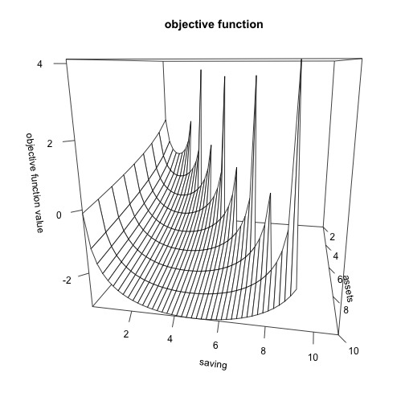

```r
src <- '
NumericVector a(a_);
NumericVector aa(aa_);
double beta  = as<double>(beta_);
NumericVector ay = log(aa);  // future values

int m = aa.length();
int n = a.length();

NumericMatrix R(n,m);

gsl_interp_accel *accP = gsl_interp_accel_alloc() ;
gsl_interp *linP = gsl_interp_alloc( gsl_interp_linear , m );
gsl_interp_init( linP, aa.begin(), ay.begin(), m );

gsl_function F;

F.function = &my_obj;

for (int i=0;i < a.length(); i++){
  // define the struct on that state
    struct my_f_params params = {a(i),beta,linP,accP,aa,ay};
    F.params   = &params;
    //Rcout << "asset state :" << i << std::endl;
    //Rcout << "asset value :" << a(i) << std::endl;
    for (int j=0; j < m; j++) {
        //Rcout << "saving value :" << aa(j) << std::endl;
        //Rcout << GSL_FN_EVAL(&F,aa(j)) << std::endl;
    R(i,j) = GSL_FN_EVAL(&F,aa(j));
    }

}
return wrap(R);
'

# here we compile the c function:
testf=cxxfunction(signature(a_="numeric",aa_="numeric",beta_="numeric"),body=src,plugin="RcppGSL",includes=inc)

# here we call it
res1 <- testf(a_=assets,aa_=saving,beta_=Beta)
tmp = res1
tmp[tmp==1e9] = NA  # the value 1e9 stands for "not feasible"
persp(tmp,theta=100,main="objective function",ticktype="detailed",x=assets,y=saving,zlab="objective function value")
```

### Setup the optimizer

this is a bit messy. needs much more commenting:

```r
src2 <- '
// map values from R
NumericVector a(a_);
NumericVector aa(aa_);
double beta = as<double>(beta_);
bool verbose = as<bool>(verbose_);
NumericVector ay = log(aa);  // future values
NumericVector R(a_);

// optimizer setup
int status;
int iter=0,max_iter=100;
const gsl_min_fminimizer_type *T;
gsl_min_fminimizer *s;

int k = aa.length();

gsl_interp_accel *accP = gsl_interp_accel_alloc() ;
gsl_interp *linP       = gsl_interp_alloc( gsl_interp_linear , k );
gsl_interp_init( linP, aa.begin(), ay.begin(), k );

// parameter struct
struct my_f_params params = {a(0),beta,linP,accP,aa,ay};

// gsl objective function
gsl_function F;
F.function = &my_obj;
F.params   = &params;

// bounds on choice variable
double low = aa(0), up=aa(k-1);
double m = 0.2; //current minium

// create an fminimizer object of type "brent"
T = gsl_min_fminimizer_brent;
s = gsl_min_fminimizer_alloc(T);

printf("using %s method\\n",
       gsl_min_fminimizer_name(s));

for (int i=0;i < a.length(); i++){

    // load current grid values into struct
    // if interpolation schemes depend on current state
    // i, need to allocate linP(i) here and then load into
    // params

    struct my_f_params params = {a(i),beta,linP,accP,aa,ay};
    F.params   = &params;

    // if optimization bounds change do that here

    low = aa(0);
    up=aa(k-1);
    iter=0; // reset iterator for each state
    m = 0.2; // reset minimum for each state

    // set minimzer on current obj function
    gsl_min_fminimizer_set( s, &F, m, low, up );

    // print results
    if (verbose){
    printf (" iter lower      upper      minimum      int.length\\n");
            printf ("%5d [%.7f, %.7f] %.7f %.7f\\n",
            iter, low, up,m, up - low);
    }

    // optimization loop
    do {
        iter++;
        status = gsl_min_fminimizer_iterate(s);
        m      = gsl_min_fminimizer_x_minimum(s);
        low    = gsl_min_fminimizer_x_lower(s);
        up     = gsl_min_fminimizer_x_upper(s);

        status = gsl_min_test_interval(low,up,0.001,0.0);

        if (status == GSL_SUCCESS && verbose){
            Rprintf("Converged:\\n");
        }
        if (verbose){
        printf ("%5d [%.7f, %.7f] %.7f %.7f\\n",
                iter, low, up,m, up - low);
        }
    }
    while (status == GSL_CONTINUE && iter < max_iter);
    R(i) = m;
}
gsl_min_fminimizer_free(s);
return wrap(R);
'
```

#### compiling the C function

```r
f2=cxxfunction(signature(a_="numeric",aa_="numeric",beta_="numeric",verbose_="logical"),body=src2,plugin="RcppGSL",includes=inc)

# setup a wrapper to call. optional
myfun <- function(ass,sav,Beta,verbose){
  res <- f2(ass,sav,Beta,verbose)
    return(res)
}

myres <- myfun(assets,saving,Beta,verbose)
```

#### look at result

we can compare the analytical solution to the one we found by just plotting the optimal savings choices:

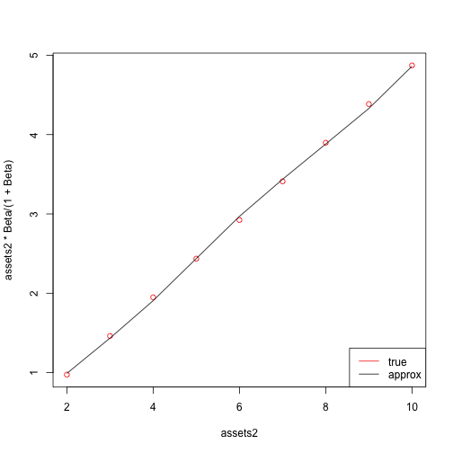

```r
plot(assets2, assets2 * Beta/(1 + Beta), col = "red")
lines(assets2, myres)
legend("bottomright", legend = c("true", "approx"), lty = c(1, 1),
    col = c("red", "black"))
```

##### How far is our solution from the closed form?

```r
print(max(assets2 * Beta/(1 + Beta) - myres))
```

```
## [1] 0.05496
```